# targeted-sequencing

Maxime Tarabichi maxime.tarabichi@gmail.com

17 March, 2020

```r
library(ASCAT.sc)
library(Biostrings)
library(GenomicRanges)
```

## ASCAT.sc on targeted sequencing from undifferentiated sarcomas

We will analyse a set of undifferentiated sarcomas (USARC) for which targeted sequencing has been performed, and for a subset, we also have access to whole-genome sequencing, which will allow to compare the profiles otbained from both approaches.

In targeted pull-down sequencing experiments, a stable ~40% of the sequenced reads are off-target, and uniformly coming from along the genome. This means that if the total number of sequenced reads is high, regardless of the number of targets in the panel, we get a shallow coverage whole-genome sequencing experiment for free.

But because the genome coverage is noisier than shallow coverage sequencing, we need to use a panel of normals to normalise the logr.

We bin the genome discounting the on-target regions and a buffer region around them. We then count the number of reads in each bin to derive a logr track, normalise it for the expected counts across a normal diploid panel sequenced using the same panel, correct for GC and other variables, and then apply the ASCAT.sc methodology to (re)fit the profiles.

### Step1: set up to run pipeline

#### Input variables

We first define: - the path directory where the BAM files and their index - ID of the normal samples: we will need normal samples processed with the same panel to normalise the logr - the path to the reference FASTA file - the window size: size of the genomic bins to count reads in - chromosome names

```r
## ##################################################
BAMDIR <- "../data/targeted"
bams <- dir(BAMDIR,full=T,pattern=".bam$")
normalids <- bams[grepl("normal",bams)]
isNormal <- sapply(bams,function(x) any(sapply(normalids,grepl,x)))
bed <- ts_treatBed(read.table("../data/targeted/3083331_Covered_b37.bed",sep="\t"),add=1000)
## ##################################################
FASTA <- "../data/targeted/hs37d5.fa"
## ##################################################
window <- 500000
## ##################################################
ALLCHR <- c(1:22)## ,"X") we leave the sex chromosome X out, as ideally the normal panel should be matched per sex.
## Load reference genome
## Doucle-check that chromosomes in the fasta are sorted the same as in ALLCHR
dna <<- getRefGenome(fasta=FASTA,CHRS=ALLCHR)
```

#### Derive the genomic bins on the off-target genome

For simplicity, here, we just bin the genome in equal-size bins of 500kb (window size), which is a good resolution for large-scale events (e.g. chromosome-arm level or large chromosome bands).

We then derive a GC track for these bins using the function *gcTrack*.

```r
####################################################
lSe <- lapply(ALLCHR,function(chr)
    getStartsEnds(window=window,
                  chr=paste0("chr",chr),
                  ##path=BINFILE,
                  ##pathBadBins=BADBINSFILE,
                  exclude=bed,
                  lengthChr=sapply(dna,length)[chr]))
names(lSe) <- ALLCHR
lExclude <- lapply(ALLCHR,function(chr)
    ts_getExcludeFromBedfile(bed,chr))
names(lExclude) <- ALLCHR
## get GC content in the bins
## should take around a few minutes to compute
lGCT <- lapply(ALLCHR,function(chr) gcTrack(chr,lSe[[chr]]$starts,lSe[[chr]]$ends,dna=dna))
##save(lGCT,file=paste0("../data/targeted/lGCT.",window,".Rda"))
##load(file=paste0("../data/targeted/lGCT.",window,".Rda"))
```

### Step2: deriving a noise profile from normal samples

Then we will derive a noise profile from the normal samples.

```r
system.time(lCTS.normal <- ts_mergeCountsNormal(bamsN=bams[isNormal],
                                                window=window,
                                                lExclude=lExclude,
                                                lSe = lSe,
                                                allchr = ALLCHR,
                                                sdNormalise = 0,
                                                mc.cores=7))
```

### Step3: count reads within bins (excluding on-target) and derive corrected logr

We then derive counts within bins, excluding on-target regions and correction for the noise seen in the normals

```r
system.time(allTracks <- mclapply(bams[!isNormal],function(bamfile)
{
    cat(".")
    kk <- try(ts_getTrackForAll.excludeTargets(bamfile,
                                               window,
                                               lExclude,
                                               lCTS.normal=lCTS.normal,
                                               lSe=lSe,
                                               lGCT=lGCT,
                                               lRepli=NULL,
                                               allchr=ALLCHR,
                                               sdNormalise=0.1),silent=T)
} , mc.cores=3)) ## 1662sec.
names(allTracks) <- gsub("../data/targeted//","",bams[!isNormal])
```

### Step4: fit solutions

Then we fit solutions for the logr track.

```r
system.time(allSols <- parallel::mclapply(1:length(allTracks),function(x)
{
    kk <- try(searchGrid(allTracks[[x]],
                   purs = seq(0.1, 1, 0.01),
                   ploidies = seq(1.7,5, 0.01),
                   maxTumourPhi=6,
                   distance="mse"),silent=T)
},mc.cores=3))
names(allSols) <- names(allTracks)
```

Let us plot one of the solutions here.

First we look at the distance matrix for all solutions on the grid.

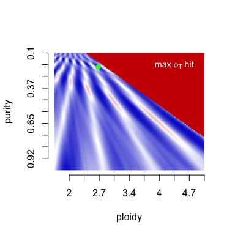

We note that there are many local minima for the total distance to integer values (dark blue) and manual refitting is almost invariably needed. If working on exomes, combining ASCAT.sc with ASCAT allow to recover potentially missed events in the non-targeted regions. The ASCAT.sc fit can then be refitted to match the ASCAT copy number profiles.

Then we look at the best fit, which minimises the distance to integer values, while respecting pre-defined built-in rules, e.g. no negative copy number, minimum size of homozygous deletions.

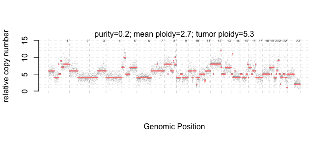

Finally we can get the corresponding copy number profile as a data frame with relevant information for downstream analyses.

```r
profile <- getProfile(fitProfile(allTracks[[1]],
                                 purity=allSols[[1]]$purity,
                                 ploidy=allSols[[1]]$ploidy))
head(profile)
```

```
#>      chromosome     start       end total_copy_number
#> [1,]          1         1  67672244                 6
#> [2,]          1  68174375 117793642                 4
#> [3,]          1 118315932 120904218                 8
#> [4,]          1 121404218 141904218                 5
#> [5,]          1 142404218 153706611                 9
#> [6,]          1 154208735 181445449                 7
#>      total_copy_number_logr         logr   logr.sd
#> [1,]               5.668696  0.039449323 0.1121082
#> [2,]               4.000262 -0.148360353 0.1328753
#> [3,]               8.120384  0.277459906 0.1256645
#> [4,]               5.249794 -0.005456283 0.0000000
#> [5,]               8.775594  0.334937577 0.1349252
#> [6,]               7.307816  0.202842174 0.0762778
```

```r
knitr::kable(profile, format="html") %>%
    kable_styling() %>%
    scroll_box(width = "100%", height = "200px")
```

| chromosome | start | end | total_copy_number | total_copy_number_logr | logr | logr.sd |
| --- | --- | --- | --- | --- | --- | --- |
| 1 | 1 | 67672244 | 6 | 5.6686956 | 0.0394493 | 0.1121082 |
| 1 | 68174375 | 117793642 | 4 | 4.0002619 | -0.1483604 | 0.1328753 |
| 1 | 118315932 | 120904218 | 8 | 8.1203845 | 0.2774599 | 0.1256645 |
| 1 | 121404218 | 141904218 | 5 | 5.2497943 | -0.0054563 | 0.0000000 |
| 1 | 142404218 | 153706611 | 9 | 8.7755937 | 0.3349376 | 0.1349252 |
| 1 | 154208735 | 181445449 | 7 | 7.3078155 | 0.2028422 | 0.0762778 |
| 1 | 181945449 | 247933570 | 8 | 7.9508944 | 0.2622111 | 0.0863175 |
| 2 | 1 | 101317308 | 6 | 5.9068661 | 0.0643711 | 0.1013762 |
| 2 | 101817308 | 242044176 | 4 | 3.8929850 | -0.1613154 | 0.1068894 |
| 3 | 1 | 97258539 | 4 | 4.0927864 | -0.1372795 | 0.1065975 |
| 3 | 97758539 | 197061513 | 6 | 6.0886149 | 0.0831035 | 0.1045695 |
| 4 | 1 | 189618417 | 4 | 3.9857810 | -0.1501023 | 0.1046525 |
| 5 | 1 | 25550333 | 7 | 7.2223183 | 0.1947618 | 0.0885853 |
| 5 | 26050333 | 46157175 | 10 | 9.7555599 | 0.4168446 | 0.0870985 |
| 5 | 46657175 | 95326824 | 5 | 5.0864932 | -0.0233477 | 0.0884704 |
| 5 | 95826824 | 179871193 | 7 | 6.7591692 | 0.1501853 | 0.0986684 |
| 6 | 1 | 44393549 | 4 | 3.6625901 | -0.1895380 | 0.1008298 |
| 6 | 44893549 | 127198071 | 4 | 4.2849650 | -0.1145325 | 0.1153938 |
| 6 | 127737961 | 170323454 | 4 | 3.7072217 | -0.1840275 | 0.1208683 |
| 7 | 1 | 70907351 | 6 | 5.9344707 | 0.0672320 | 0.1028502 |
| 7 | 71407351 | 76418092 | 8 | 8.1351161 | 0.2787777 | 0.0908687 |
| 7 | 76918092 | 158449036 | 6 | 6.1313104 | 0.0874690 | 0.0950292 |
| 8 | 1 | 43481557 | 8 | 7.8927154 | 0.2569394 | 0.0974042 |
| 8 | 43983706 | 45983706 | 5 | 5.2497943 | -0.0054563 | 0.0000000 |
| 8 | 46483706 | 76260656 | 8 | 7.9176400 | 0.2592002 | 0.1134713 |
| 8 | 76760656 | 90309491 | 6 | 6.2224058 | 0.0967393 | 0.0738458 |
| 8 | 90809491 | 91866127 | 8 | 8.4777828 | 0.3090959 | 0.0597003 |
| 8 | 92366127 | 94870379 | 16 | 16.3969824 | 0.8752765 | 0.1912091 |
| 8 | 95372512 | 108480476 | 6 | 5.6057356 | 0.0327887 | 0.1375291 |
| 8 | 109021772 | 113561679 | 9 | 8.5546015 | 0.3158060 | 0.0820282 |

[output cut: 56 more lines]

We refer to the methylation-data vignette for manual refitting, which works the same way (except here the gamma can be left to default of gamma=1).

### All profiles

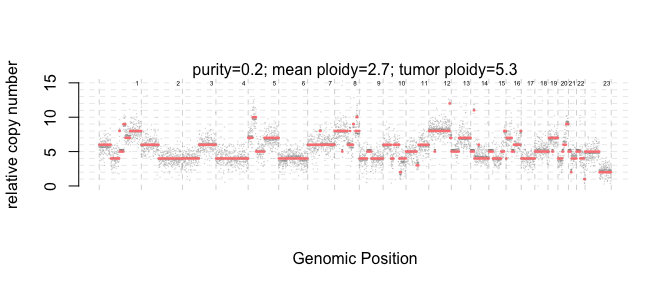

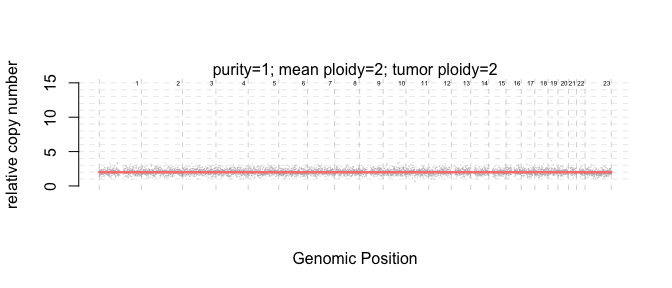

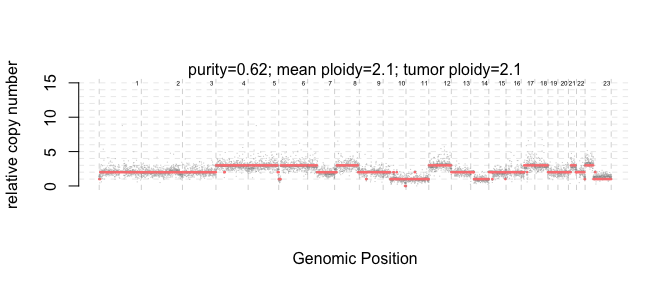

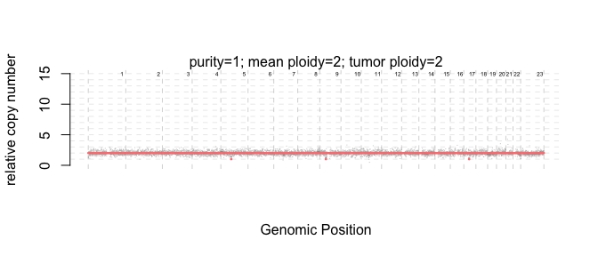

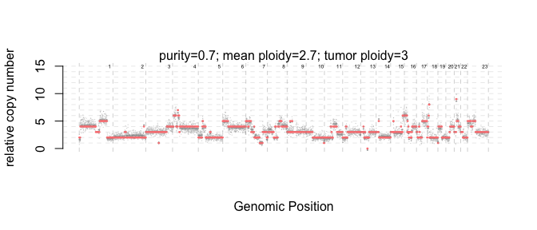

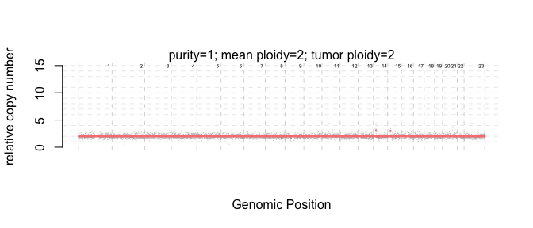

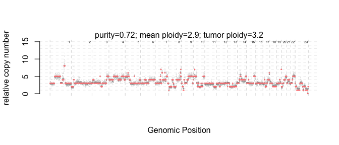

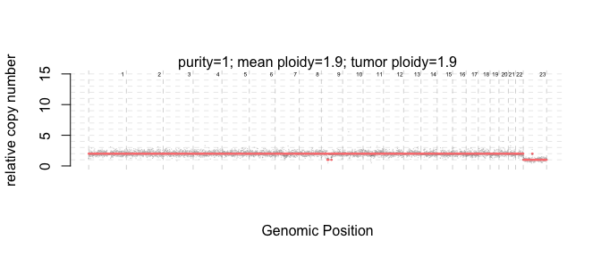

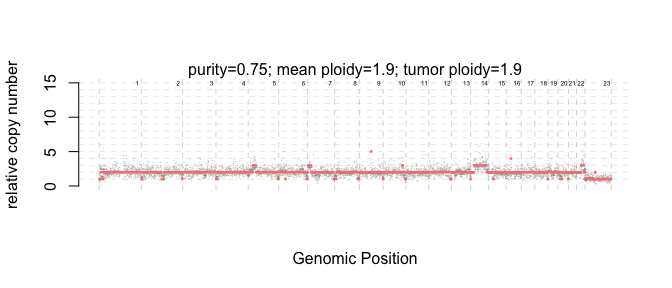

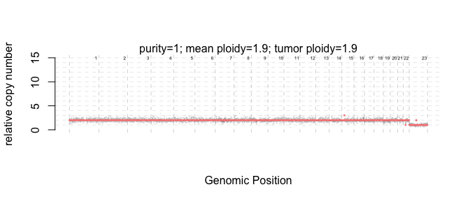

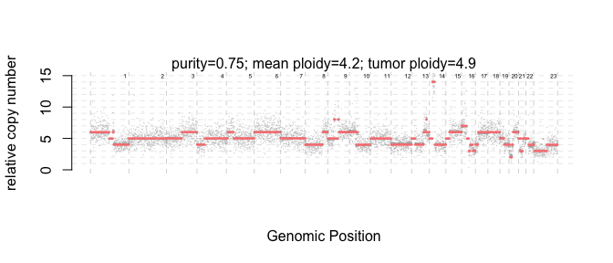

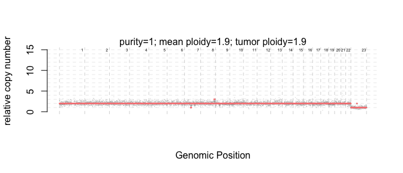

[42 more figures not shown]